# World CO₂ Emissions Growth with Dashboard using Tableau

Tableau

Data Visualization

A guide to create an effective and clear dashboard for better understand average CO₂ in the world using CO₂ dataset.

Miftahul Hadi  
Dec 20, 2022

## Introduction

According to [the World Meteorological Organization’s (WMO)](https://public.wmo.int/en/media/press-release/eight-warmest-years-record-witness-upsurge-climate-change-impacts#:~:text=Temperature%3A%20The%20global%20average%20temperature,until%20the%20end%20of%202022.), the past eight years are the warmest Earth temperature on record. To better understand about this climate changes, I want to design a dashboard about **World CO₂ Emissions Growth**. This dashboard will review the average CO₂ that produced in every country. Then, we try to investigate the production growth over the year in every region. Hopefully, this dashboard will be beneficial to reduces and mitigates the effects of [global climate changes](https://www.lse.ac.uk/granthaminstitute/news/economic-co-benefits-of-reducing-co2-emissions-outweigh-the-cost-of-mitigation-for-most-big-emitters/).

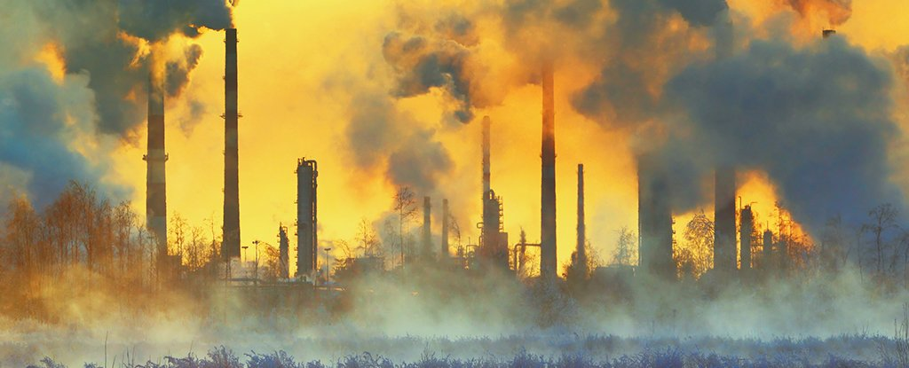

**Fig. 1.** The spreading of factory residue

Here, we used the data sets from [The World Bank Group](http://data.worldbank.org/indicator/EN.ATM.CO2E.PC), a world organization that work to reduce poverty in a country. This data sets include several variable such as:

- Country Name
- Year of CO₂ collected
- CO₂ per Capita.

### What to analyze?

This data set can be used to find a questions that might arise such as:

- Which country/region has the most average CO₂ per capita?
- What region has the highest growth of CO₂ emitters?

Hopefully, this questions will be a step to reveal what inside the data sets and helps other countries to mitigate the global climate changes.

## Preparation

Here, I want to describe a few tools used in this analysis:

1. [Tableau Public](https://public.tableau.com/app/discover)
2. Excel (*for storing data*)
3. [CO₂ Dataset](http://data.worldbank.org/indicator/EN.ATM.CO2E.PC)

## Create a Dashboard

Here’s a step-by-step to create a clear dashboard about CO₂ growth. You can click every step to show the detailed :

**Load the Dataset**

To connect the dataset to Tableau, the step as follows:

- First, open Tableau Public application.
- Then, the first window you see might be like this.

[figure not shown]

- Select **Microsoft Excel** (*because our dataset is in excel format*), then locate to the dataset file.
- Next, a lot of sheet inside of dataset will appear. This is Data Source window.

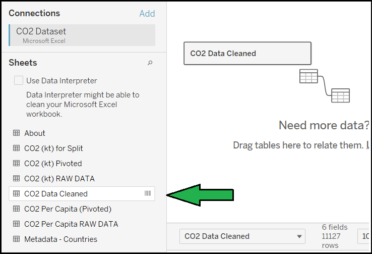

- Connect the Tableau to useful sheet that already been cleaned. Here, we choose `CO2 Data Cleaned` because the sheet involves metrics needed.
- Last, we can go to worksheet

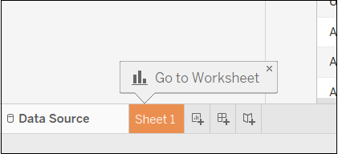

As a preview, here is a view of Tableau project we work on.

[figure not shown]

As the image above, there are three sections that show up, including:

- **Left-side** = Where the data stored.
- **Middle** = Tools to refine your data visualization.
- **Right-side** = Place to view your visualization.

**Create a Graph**

In this section, we want plotting the dataset about CO₂ activity in the World to answers question.

#### Average CO₂ per Capita

Here’s the step to create a clear graph of average CO₂ for every country:

- First, we put the `Country Name` column to **Detail** in Marks pane.

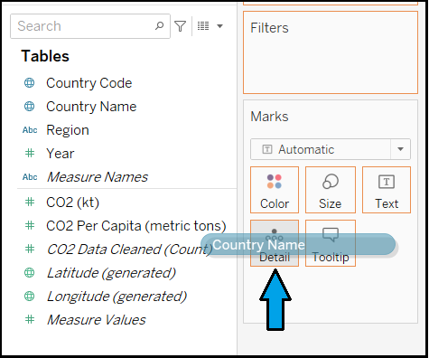

- A map will appear with the country as a data points.

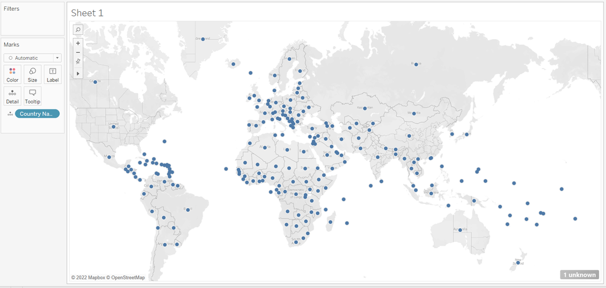

- Then, we calculate the average CO₂ per Capita for every country by **drag** the `CO2 Per Capita (metric tons)` column to **Size** in Marks pane.

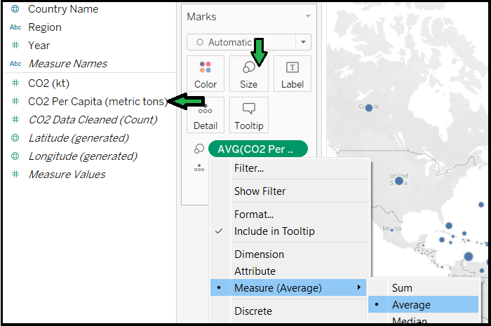

- Average of CO₂ per Capita will appear with circle size. The larger the circle, the highest average.

[figure not shown]

- Then, we can **add a color divergence** on the circle to make the average CO₂ per capita more clear.

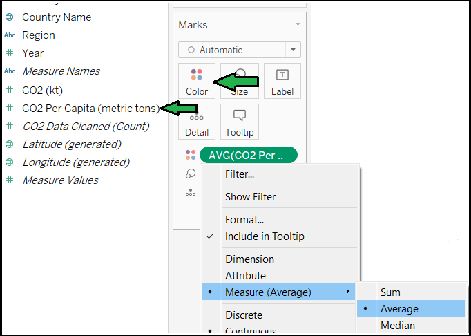

- Then, we can see the divergence of color in the circle. The higher the blue concentrate, higher the average.

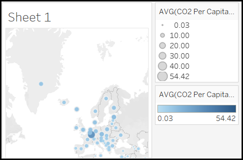

- To make it more clear, we can change the color from Blue to Red-Green.
- Click **Edit Colors**, make the colors reversed, because green indicate low CO₂ and red for high CO₂. Make the center to 4.

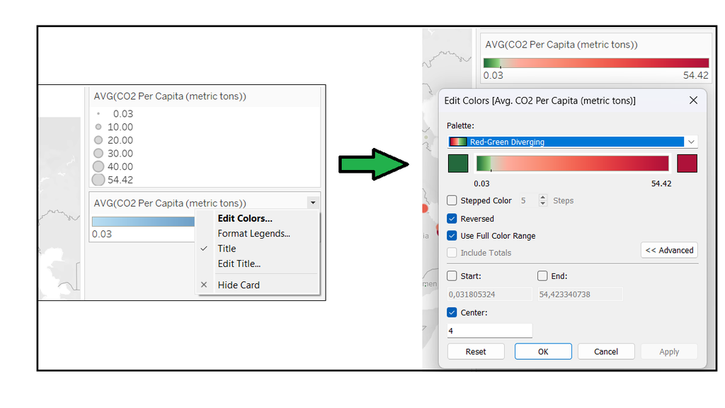

- Make the size of the circle correlated to average CO₂ per Capita.

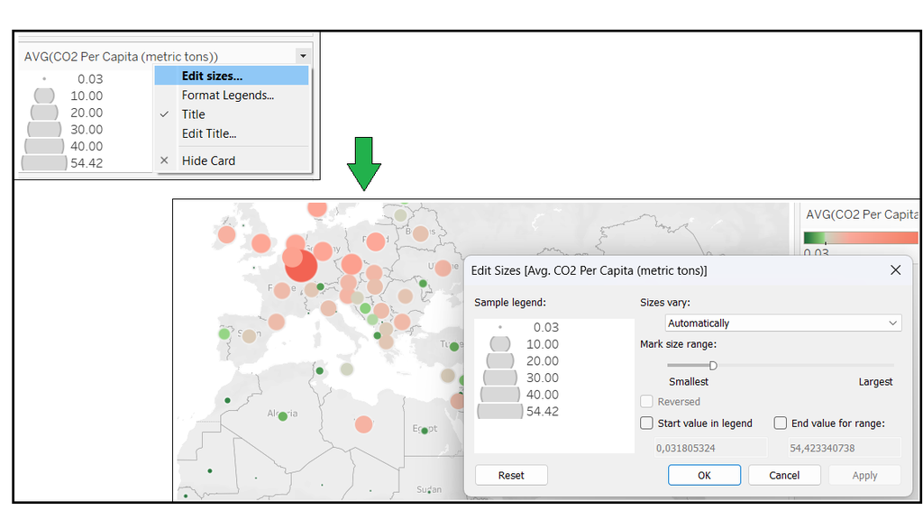

- Add a border color on circle.

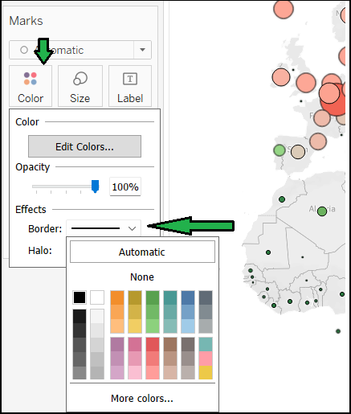

- Change the title and this is the first graph for **Average CO₂ per Capita**.

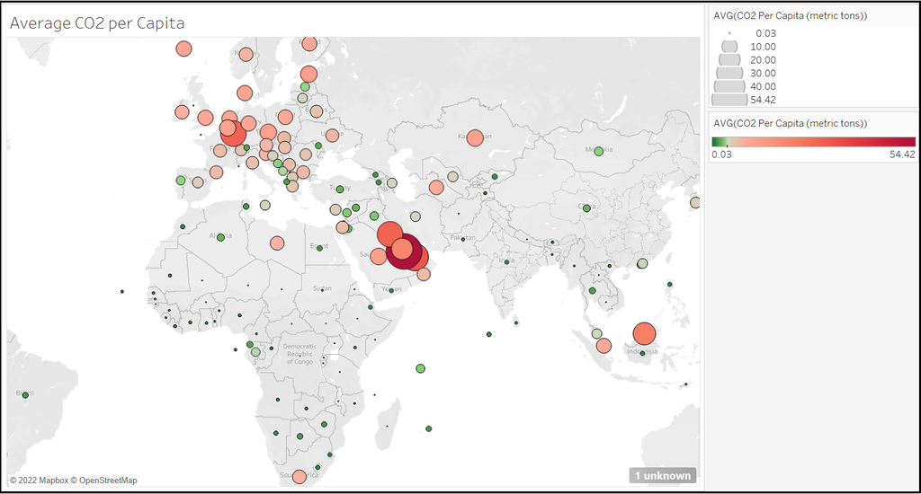

#### CO₂ Production by Region

Here’s the step to a viz about CO₂ production over the years:

- First, add a new worksheet for different graph.

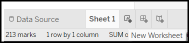

- Add `Region` column on **color marks**.

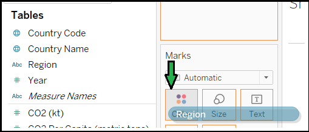

- Then, add `Year` as a columns & `CO2 (kt)` as a rows.

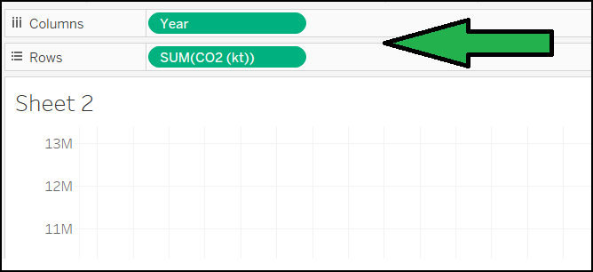

- Here’s the graph. You see that the year is too crowded.

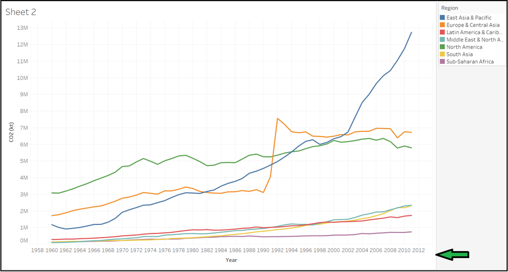

- Make it only per 10 years by ranges.

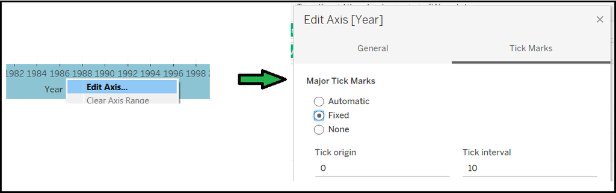

- There you go. Here the graph explain about CO₂ production by Region

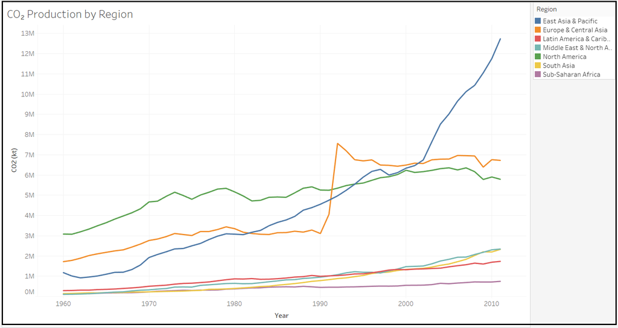

Next, we can combine this two graph to design a clear dashboard.

**Design the dashboard**

In this section, we want to combine two graph we have created into one dashboard. Here’s the step:

- First, create a **new dashboard**.

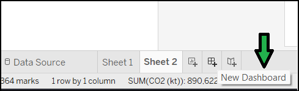

- Let’s add two graph we’ve created before by **dragging the sheet** into canvas.

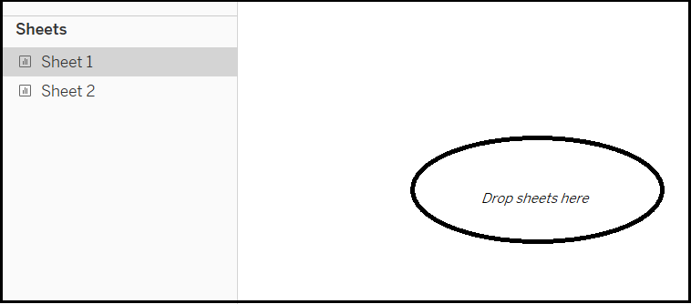

- After dragging two graph. Then, it will looks like this.

[figure not shown]

- Notice that the legend is kind of confusing. Let’s move it into the relevant graph.
- To move the legend, first click **More options**, then choose **Floating**.

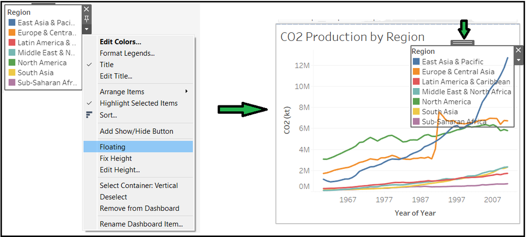

- Do this with color divergence legend. Delete the circle legend.
- Then, **remove** the unused container to make the dashboard more clear.

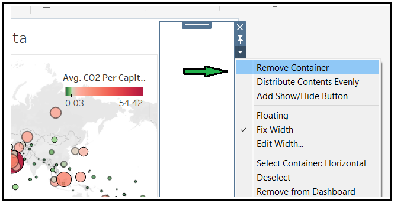

**Final dashboard**

Here’s the final dashboard that we have created.

[figure not shown]

Now, the legend is tied with each graph. It’s give a context to graph and make the dashboard more clear.

## Analysis

### Average CO₂ per capita

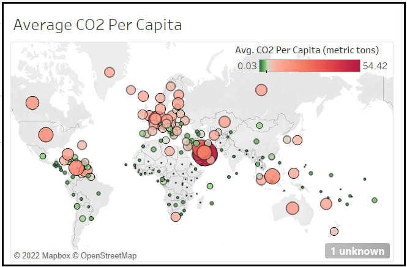

This graph describes the average of CO₂ per capita in every country, between 1960 and 2011. The circle shows where the country is. Darker red or bigger circles indicate the country produces more CO₂ than the others. Darker the green or smaller circles, the less CO₂ to be produced.

From the graph above, we can see that the Middle-east country has the **highest average CO₂ per capita**. For example, Qatar (*one of the Middle-east countries*) has an average of 54.42 tons per capita. It means that Qatari people have produced more CO₂ than any other country in the world. This is because of [Qatar’s heavy reliance](https://www.ecomena.org/qatar-ecological-footprint/) on gas and oil and has relatively [small population](https://www.qscience.com/content/papers/10.5339/qfarc.2018.EEPD592#:~:text=Qatar%20has%20the%20highest%20CO2,gas%20reserves%20in%20the%20world.) when compared to other countries. This make the average larger. There’s also UAE (31.84 tons), Kuwait (28.4 tons), Bahrain (19.87 tons), and others.

On the opposite, most of Africa and South America country has the **lowest average CO₂ per capita**. Chad (*one of the African countries*) has the average of 0.03 tons per capita, the lowest in the world.

### Growth of CO₂ emitters

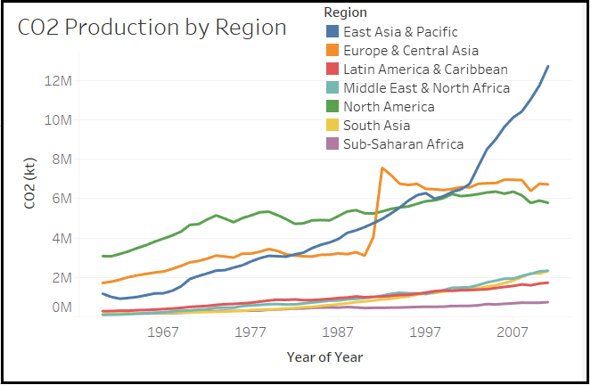

This graph describes the CO₂ production growth in a number of regions between 1960 and 2011. Here, the CO₂ production is measured by kilo ton (kt). Each region shows in a colored line.

From the graph above, each region tend to produce more CO₂ every year. In 1960, the highest CO₂ emitter is North America region. But 50 years later, East Asia & Pacific has produces more CO₂ than any others region.

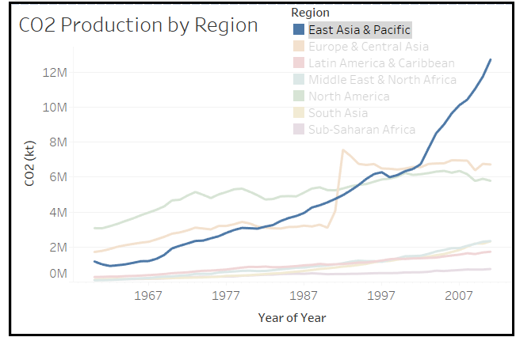

In the graph above, we can see the rapid increase of CO₂ production in East Asia & Pacific from 1960 to 2011. In 1960, the CO₂ production is about 1,17 billion tons. 40 years later, the production is increased by 6 times (6,34 billion tons). It took only 10 years later to get 12,74 billion tons. This indicates that the **increase rate of CO₂ production in East Asia & Pacific** is significant.

## Conclusion

According to this analysis, we find that Qatar’s reliance on Gas and Oil makes the country the highest average of CO₂ per capita with 54.42 tons produced. But, the growth of CO₂ production in East Asia & Pacific should be wary with only 10 years from 2000, the CO₂ production increased 2 times higher by 12,74 billion tons.

### Suggestion

For the next analysis, a population dataset is needed for better little-bias analysis. Because, [Qatar with less population](https://www.qscience.com/content/papers/10.5339/qfarc.2018.EEPD592#:~:text=Qatar%20has%20the%20highest%20CO2,gas%20reserves%20in%20the%20world.) could get a higher average of CO₂ per capita than other countries with a higher population.

### Source

- Deardorff, A., 2016. Tableau (version. 9.1). Journal of the Medical Library Association, 104(2), pp.182-183.
- Sheikh, S. E. (2022) ‘Eight warmest years on record witness upsurge in climate change impacts’, *World Meteorological Organization*, 6 Nov. Available at: [https://public.wmo.int/en/media/press-release/eight-warmest-years-record-witness-upsurge-climate-change-impacts](https://public.wmo.int/en/media/press-release/eight-warmest-years-record-witness-upsurge-climate-change-impacts#:~:text=Temperature%3A%20The%20global%20average%20temperature,until%20the%20end%20of%202022.)
- Hamilton, K. (2017) ‘Economic co-benefits of reducing CO2 emissions outweigh the cost of mitigation for most big emitters’, *The London School of Economics and Political Science*, 3 Nov. Available at: https://www.lse.ac.uk/granthaminstitute/news/economic-co-benefits-of-reducing-co2-emissions-outweigh-the-cost-of-mitigation-for-most-big-emitters/
- Climate Watch Org. (2020) ‘CO2 emissions (metric tons per capita)’. Available at: http://data.worldbank.org/indicator/EN.ATM.CO2E.PC
- Adema, S. (2022) ‘Understanding Qatar’s Ecological Footprint’, *Ecomena*, 1 March. Available at: https://www.ecomena.org/qatar-ecological-footprint/
- Al-Asmakh, M. and Al-Awainati, N., 2018, March. Counting the Carbon: Assessing Qatar’s Carbon Dioxide Emissions. In Qatar Foundation Annual Research Conference Proceedings Volume 2018 Issue 1 (Vol. 2018, No. 1, p. EEPD592). Hamad bin Khalifa University Press (HBKU Press).